# Credit Card Users Churn Prediction

## Problem Statement

### Business Context

The Thera bank recently saw a steep decline in the number of users of their credit card, credit cards are a good source of income for banks because of different kinds of fees charged by the banks like annual fees, balance transfer fees, and cash advance fees, late payment fees, foreign transaction fees, and others. Some fees are charged to every user irrespective of usage, while others are charged under specified circumstances.

Customers’ leaving credit cards services would lead bank to loss, so the bank wants to analyze the data of customers and identify the customers who will leave their credit card services and reason for same – so that bank could improve upon those areas

You as a Data scientist at Thera bank need to come up with a classification model that will help the bank improve its services so that customers do not renounce their credit cards

### Data Description

- CLIENTNUM: Client number. Unique identifier for the customer holding the account
- Attrition_Flag: Internal event (customer activity) variable - if the account is closed then "Attrited Customer" else "Existing Customer"
- Customer_Age: Age in Years
- Gender: Gender of the account holder
- Dependent_count: Number of dependents
- Education_Level: Educational Qualification of the account holder - Graduate, High School, Unknown, Uneducated, College(refers to college student), Post-Graduate, Doctorate
- Marital_Status: Marital Status of the account holder
- Income_Category: Annual Income Category of the account holder
- Card_Category: Type of Card
- Months_on_book: Period of relationship with the bank (in months)
- Total_Relationship_Count: Total no. of products held by the customer
- Months_Inactive_12_mon: No. of months inactive in the last 12 months
- Contacts_Count_12_mon: No. of Contacts in the last 12 months
- Credit_Limit: Credit Limit on the Credit Card
- Total_Revolving_Bal: Total Revolving Balance on the Credit Card
- Avg_Open_To_Buy: Open to Buy Credit Line (Average of last 12 months)
- Total_Amt_Chng_Q4_Q1: Change in Transaction Amount (Q4 over Q1)
- Total_Trans_Amt: Total Transaction Amount (Last 12 months)
- Total_Trans_Ct: Total Transaction Count (Last 12 months)
- Total_Ct_Chng_Q4_Q1: Change in Transaction Count (Q4 over Q1)
- Avg_Utilization_Ratio: Average Card Utilization Ratio

#### What Is a Revolving Balance?

- If we don't pay the balance of the revolving credit account in full every month, the unpaid portion carries over to the next month. That's called a revolving balance

##### What is the Average Open to buy?

- 'Open to Buy' means the amount left on your credit card to use. Now, this column represents the average of this value for the last 12 months.

##### What is the Average utilization Ratio?

- The Avg_Utilization_Ratio represents how much of the available credit the customer spent. This is useful for calculating credit scores.

##### Relation b/w Avg_Open_To_Buy, Credit_Limit and Avg_Utilization_Ratio:

- ( Avg_Open_To_Buy / Credit_Limit ) + Avg_Utilization_Ratio = 1

### **Please read the instructions carefully before starting the project.**

This is a commented Jupyter IPython Notebook file in which all the instructions and tasks to be performed are mentioned.

- Blanks '**___**' are provided in the notebook that needs to be filled with an appropriate code to get the correct result. With every '**___**' blank, there is a comment that briefly describes what needs to be filled in the blank space.
- Identify the task to be performed correctly, and only then proceed to write the required code.
- Fill the code wherever asked by the commented lines like "# write your code here" or "# complete the code". Running incomplete code may throw error.
- Please run the codes in a sequential manner from the beginning to avoid any unnecessary errors.
- Add the results/observations (wherever mentioned) derived from the analysis in the presentation and submit the same.

## Importing necessary libraries

```python
# To help with reading and manipulating data
import pandas as pd
import numpy as np

# To help with data visualization
%matplotlib inline
import matplotlib.pyplot as plt
import seaborn as sns

# To be used for missing value imputation
from sklearn.impute import SimpleImputer

# To help with model building
from sklearn.linear_model import LogisticRegression
from sklearn.tree import DecisionTreeClassifier
from sklearn.ensemble import (
    AdaBoostClassifier,
    GradientBoostingClassifier,
    RandomForestClassifier,
    BaggingClassifier,
)

# To get different metric scores, and split data
from sklearn import metrics
from sklearn.model_selection import train_test_split, StratifiedKFold, cross_val_score
from sklearn.metrics import (
    f1_score,
    accuracy_score,
    recall_score,
    precision_score,
    confusion_matrix,
    roc_auc_score,
    plot_confusion_matrix,
)

# To be used for data scaling and one hot encoding
from sklearn.preprocessing import StandardScaler, MinMaxScaler, OneHotEncoder


# To be used for tuning the model
from sklearn.model_selection import GridSearchCV, RandomizedSearchCV

# To be used for creating pipelines and personalizing them
from sklearn.pipeline import Pipeline
from sklearn.compose import ColumnTransformer
from sklearn.preprocessing import FunctionTransformer

# To oversample and undersample data
from imblearn.over_sampling import SMOTE
from imblearn.under_sampling import RandomUnderSampler

# To define maximum number of columns to be displayed in a dataframe
pd.set_option("display.max_columns", None)

# To supress scientific notations for a dataframe
pd.set_option("display.float_format", lambda x: "%.3f" % x)

# To supress warnings
import warnings

warnings.filterwarnings("ignore")
```

## Loading the dataset

```python
data = pd.read_csv("BankChurners.csv")
```

## Data Overview

```python
# let's create a copy of the data
df = data.copy()
```

- Observations
- Sanity checks

```python
# let's view the first 10 rows of the data
df.head(10)
```

|  | CLIENTNUM | Attrition_Flag | Customer_Age | Gender | Dependent_count | Education_Level | Marital_Status | Income_Category | Card_Category | Months_on_book | Total_Relationship_Count | Months_Inactive_12_mon | Contacts_Count_12_mon | Credit_Limit | Total_Revolving_Bal | Avg_Open_To_Buy | Total_Amt_Chng_Q4_Q1 | Total_Trans_Amt | Total_Trans_Ct | Total_Ct_Chng_Q4_Q1 | Avg_Utilization_Ratio |
| --- | --- | --- | --- | --- | --- | --- | --- | --- | --- | --- | --- | --- | --- | --- | --- | --- | --- | --- | --- | --- | --- |
| 0 | 768805383 | Existing Customer | 45 | M | 3 | High School | Married | $60K - $80K | Blue | 39 | 5 | 1 | 3 | 12691.000 | 777 | 11914.000 | 1.335 | 1144 | 42 | 1.625 | 0.061 |
| 1 | 818770008 | Existing Customer | 49 | F | 5 | Graduate | Single | Less than $40K | Blue | 44 | 6 | 1 | 2 | 8256.000 | 864 | 7392.000 | 1.541 | 1291 | 33 | 3.714 | 0.105 |
| 2 | 713982108 | Existing Customer | 51 | M | 3 | Graduate | Married | $80K - $120K | Blue | 36 | 4 | 1 | 0 | 3418.000 | 0 | 3418.000 | 2.594 | 1887 | 20 | 2.333 | 0.000 |
| 3 | 769911858 | Existing Customer | 40 | F | 4 | High School | NaN | Less than $40K | Blue | 34 | 3 | 4 | 1 | 3313.000 | 2517 | 796.000 | 1.405 | 1171 | 20 | 2.333 | 0.760 |
| 4 | 709106358 | Existing Customer | 40 | M | 3 | Uneducated | Married | $60K - $80K | Blue | 21 | 5 | 1 | 0 | 4716.000 | 0 | 4716.000 | 2.175 | 816 | 28 | 2.500 | 0.000 |
| 5 | 713061558 | Existing Customer | 44 | M | 2 | Graduate | Married | $40K - $60K | Blue | 36 | 3 | 1 | 2 | 4010.000 | 1247 | 2763.000 | 1.376 | 1088 | 24 | 0.846 | 0.311 |
| 6 | 810347208 | Existing Customer | 51 | M | 4 | NaN | Married | $120K + | Gold | 46 | 6 | 1 | 3 | 34516.000 | 2264 | 32252.000 | 1.975 | 1330 | 31 | 0.722 | 0.066 |
| 7 | 818906208 | Existing Customer | 32 | M | 0 | High School | NaN | $60K - $80K | Silver | 27 | 2 | 2 | 2 | 29081.000 | 1396 | 27685.000 | 2.204 | 1538 | 36 | 0.714 | 0.048 |
| 8 | 710930508 | Existing Customer | 37 | M | 3 | Uneducated | Single | $60K - $80K | Blue | 36 | 5 | 2 | 0 | 22352.000 | 2517 | 19835.000 | 3.355 | 1350 | 24 | 1.182 | 0.113 |
| 9 | 719661558 | Existing Customer | 48 | M | 2 | Graduate | Single | $80K - $120K | Blue | 36 | 6 | 3 | 3 | 11656.000 | 1677 | 9979.000 | 1.524 | 1441 | 32 | 0.882 | 0.144 |

```python
# let's view the last 10 rows of the data
df.tail(10)
```

|  | CLIENTNUM | Attrition_Flag | Customer_Age | Gender | Dependent_count | Education_Level | Marital_Status | Income_Category | Card_Category | Months_on_book | Total_Relationship_Count | Months_Inactive_12_mon | Contacts_Count_12_mon | Credit_Limit | Total_Revolving_Bal | Avg_Open_To_Buy | Total_Amt_Chng_Q4_Q1 | Total_Trans_Amt | Total_Trans_Ct | Total_Ct_Chng_Q4_Q1 | Avg_Utilization_Ratio |
| --- | --- | --- | --- | --- | --- | --- | --- | --- | --- | --- | --- | --- | --- | --- | --- | --- | --- | --- | --- | --- | --- |
| 10117 | 712503408 | Existing Customer | 57 | M | 2 | Graduate | Married | $80K - $120K | Blue | 40 | 6 | 3 | 4 | 17925.000 | 1909 | 16016.000 | 0.712 | 17498 | 111 | 0.820 | 0.106 |
| 10118 | 713755458 | Attrited Customer | 50 | M | 1 | NaN | NaN | $80K - $120K | Blue | 36 | 6 | 3 | 4 | 9959.000 | 952 | 9007.000 | 0.825 | 10310 | 63 | 1.100 | 0.096 |
| 10119 | 716893683 | Attrited Customer | 55 | F | 3 | Uneducated | Single | abc | Blue | 47 | 4 | 3 | 3 | 14657.000 | 2517 | 12140.000 | 0.166 | 6009 | 53 | 0.514 | 0.172 |
| 10120 | 710841183 | Existing Customer | 54 | M | 1 | High School | Single | $60K - $80K | Blue | 34 | 5 | 2 | 0 | 13940.000 | 2109 | 11831.000 | 0.660 | 15577 | 114 | 0.754 | 0.151 |
| 10121 | 713899383 | Existing Customer | 56 | F | 1 | Graduate | Single | Less than $40K | Blue | 50 | 4 | 1 | 4 | 3688.000 | 606 | 3082.000 | 0.570 | 14596 | 120 | 0.791 | 0.164 |
| 10122 | 772366833 | Existing Customer | 50 | M | 2 | Graduate | Single | $40K - $60K | Blue | 40 | 3 | 2 | 3 | 4003.000 | 1851 | 2152.000 | 0.703 | 15476 | 117 | 0.857 | 0.462 |
| 10123 | 710638233 | Attrited Customer | 41 | M | 2 | NaN | Divorced | $40K - $60K | Blue | 25 | 4 | 2 | 3 | 4277.000 | 2186 | 2091.000 | 0.804 | 8764 | 69 | 0.683 | 0.511 |
| 10124 | 716506083 | Attrited Customer | 44 | F | 1 | High School | Married | Less than $40K | Blue | 36 | 5 | 3 | 4 | 5409.000 | 0 | 5409.000 | 0.819 | 10291 | 60 | 0.818 | 0.000 |
| 10125 | 717406983 | Attrited Customer | 30 | M | 2 | Graduate | NaN | $40K - $60K | Blue | 36 | 4 | 3 | 3 | 5281.000 | 0 | 5281.000 | 0.535 | 8395 | 62 | 0.722 | 0.000 |
| 10126 | 714337233 | Attrited Customer | 43 | F | 2 | Graduate | Married | Less than $40K | Silver | 25 | 6 | 2 | 4 | 10388.000 | 1961 | 8427.000 | 0.703 | 10294 | 61 | 0.649 | 0.189 |

## Observations

1. There are some NaN in some columns.
2. Also there is 'abc' shown under `Income_Category`

```python
# Let's check the shape of the dataset
print(f"There are {df.shape[0]} rows and {df.shape[1]} columns.")  # f-string
```

```
There are 10127 rows and 21 columns.
```

```python
# let's check the data types of the columns in the dataset
df.info()
```

```
<class 'pandas.core.frame.DataFrame'>
RangeIndex: 10127 entries, 0 to 10126
Data columns (total 21 columns):
 #   Column                    Non-Null Count  Dtype
---  ------                    --------------  -----
 0   CLIENTNUM                 10127 non-null  int64
 1   Attrition_Flag            10127 non-null  object
 2   Customer_Age              10127 non-null  int64
 3   Gender                    10127 non-null  object
 4   Dependent_count           10127 non-null  int64
 5   Education_Level           8608 non-null   object
 6   Marital_Status            9378 non-null   object
 7   Income_Category           10127 non-null  object
 8   Card_Category             10127 non-null  object
 9   Months_on_book            10127 non-null  int64
 10  Total_Relationship_Count  10127 non-null  int64
 11  Months_Inactive_12_mon    10127 non-null  int64
 12  Contacts_Count_12_mon     10127 non-null  int64
 13  Credit_Limit              10127 non-null  float64
 14  Total_Revolving_Bal       10127 non-null  int64
 15  Avg_Open_To_Buy           10127 non-null  float64
 16  Total_Amt_Chng_Q4_Q1      10127 non-null  float64
 17  Total_Trans_Amt           10127 non-null  int64
 18  Total_Trans_Ct            10127 non-null  int64
 19  Total_Ct_Chng_Q4_Q1       10127 non-null  float64
 20  Avg_Utilization_Ratio     10127 non-null  float64
dtypes: float64(5), int64(10), object(6)
memory usage: 1.6+ MB
```

## Observations

1. `Education_Level` and `Maritial_Status` have missing numbers. We will deal with these later.
2. Majority of the columns are either int or float.
3. 6 columns are of object type.

```python
# Let's convert the columns with an 'object' datatype into categorical variables
for feature in df.columns: # Loop through all columns in the dataframe
    if df[feature].dtype == 'object': # Only apply for columns with categorical strings
        df[feature] = pd.Categorical(df[feature])# Replace strings with an integer
df.info()
```

```
<class 'pandas.core.frame.DataFrame'>
RangeIndex: 10127 entries, 0 to 10126
Data columns (total 21 columns):
 #   Column                    Non-Null Count  Dtype
---  ------                    --------------  -----
 0   CLIENTNUM                 10127 non-null  int64
 1   Attrition_Flag            10127 non-null  category
 2   Customer_Age              10127 non-null  int64
 3   Gender                    10127 non-null  category
 4   Dependent_count           10127 non-null  int64
 5   Education_Level           8608 non-null   category
 6   Marital_Status            9378 non-null   category
 7   Income_Category           10127 non-null  category
 8   Card_Category             10127 non-null  category
 9   Months_on_book            10127 non-null  int64
 10  Total_Relationship_Count  10127 non-null  int64
 11  Months_Inactive_12_mon    10127 non-null  int64
 12  Contacts_Count_12_mon     10127 non-null  int64
 13  Credit_Limit              10127 non-null  float64
 14  Total_Revolving_Bal       10127 non-null  int64
 15  Avg_Open_To_Buy           10127 non-null  float64
 16  Total_Amt_Chng_Q4_Q1      10127 non-null  float64
 17  Total_Trans_Amt           10127 non-null  int64
 18  Total_Trans_Ct            10127 non-null  int64
 19  Total_Ct_Chng_Q4_Q1       10127 non-null  float64
 20  Avg_Utilization_Ratio     10127 non-null  float64
dtypes: category(6), float64(5), int64(10)
memory usage: 1.2 MB
```

Object has been converted to categorical values.

```python
# let's check for duplicate values
df.duplicated().sum()
```

```
0
```

There are no duplicate values in the dataset

```python
# Let's check for percentage of missing values
round(df.isnull().sum() / df.isnull().count() * 100, 2)
```

```
CLIENTNUM                   0.000
Attrition_Flag              0.000
Customer_Age                0.000
Gender                      0.000
Dependent_count             0.000
Education_Level            15.000
Marital_Status              7.400
Income_Category             0.000
Card_Category               0.000
Months_on_book              0.000
Total_Relationship_Count    0.000
Months_Inactive_12_mon      0.000
Contacts_Count_12_mon       0.000
Credit_Limit                0.000
Total_Revolving_Bal         0.000
Avg_Open_To_Buy             0.000
Total_Amt_Chng_Q4_Q1        0.000
Total_Trans_Amt             0.000
Total_Trans_Ct              0.000
Total_Ct_Chng_Q4_Q1         0.000
Avg_Utilization_Ratio       0.000
dtype: float64
```

## Observations

1. 15% of the `Education_Level` values are missing.
2. over 7% of the `Marital_Status` values are missing.
3. The remaining columns do not show any missing values

```python
# let's view the statistical summary of the numerical columns in the data
df.describe().T
```

|  | count | mean | std | min | 25% | 50% | 75% | max |
| --- | --- | --- | --- | --- | --- | --- | --- | --- |
| CLIENTNUM | 10127.000 | 739177606.334 | 36903783.450 | 708082083.000 | 713036770.500 | 717926358.000 | 773143533.000 | 828343083.000 |
| Customer_Age | 10127.000 | 46.326 | 8.017 | 26.000 | 41.000 | 46.000 | 52.000 | 73.000 |
| Dependent_count | 10127.000 | 2.346 | 1.299 | 0.000 | 1.000 | 2.000 | 3.000 | 5.000 |
| Months_on_book | 10127.000 | 35.928 | 7.986 | 13.000 | 31.000 | 36.000 | 40.000 | 56.000 |
| Total_Relationship_Count | 10127.000 | 3.813 | 1.554 | 1.000 | 3.000 | 4.000 | 5.000 | 6.000 |
| Months_Inactive_12_mon | 10127.000 | 2.341 | 1.011 | 0.000 | 2.000 | 2.000 | 3.000 | 6.000 |
| Contacts_Count_12_mon | 10127.000 | 2.455 | 1.106 | 0.000 | 2.000 | 2.000 | 3.000 | 6.000 |
| Credit_Limit | 10127.000 | 8631.954 | 9088.777 | 1438.300 | 2555.000 | 4549.000 | 11067.500 | 34516.000 |
| Total_Revolving_Bal | 10127.000 | 1162.814 | 814.987 | 0.000 | 359.000 | 1276.000 | 1784.000 | 2517.000 |
| Avg_Open_To_Buy | 10127.000 | 7469.140 | 9090.685 | 3.000 | 1324.500 | 3474.000 | 9859.000 | 34516.000 |
| Total_Amt_Chng_Q4_Q1 | 10127.000 | 0.760 | 0.219 | 0.000 | 0.631 | 0.736 | 0.859 | 3.397 |
| Total_Trans_Amt | 10127.000 | 4404.086 | 3397.129 | 510.000 | 2155.500 | 3899.000 | 4741.000 | 18484.000 |
| Total_Trans_Ct | 10127.000 | 64.859 | 23.473 | 10.000 | 45.000 | 67.000 | 81.000 | 139.000 |
| Total_Ct_Chng_Q4_Q1 | 10127.000 | 0.712 | 0.238 | 0.000 | 0.582 | 0.702 | 0.818 | 3.714 |
| Avg_Utilization_Ratio | 10127.000 | 0.275 | 0.276 | 0.000 | 0.023 | 0.176 | 0.503 | 0.999 |

## Observations

```python
df.describe(include=["category"]).T
```

|  | count | unique | top | freq |
| --- | --- | --- | --- | --- |
| Attrition_Flag | 10127 | 2 | Existing Customer | 8500 |
| Gender | 10127 | 2 | F | 5358 |
| Education_Level | 8608 | 6 | Graduate | 3128 |
| Marital_Status | 9378 | 3 | Married | 4687 |
| Income_Category | 10127 | 6 | Less than $40K | 3561 |
| Card_Category | 10127 | 4 | Blue | 9436 |

## Observations

- There are more existing customers than attrited customers.
- There are more slightly more females than mmales.
- The most common `Education_Level` is graduate.
- The most common `Marital_Status` is married.
- The most common `Income_Category` is Less than 40K.
- The most common `Card_Category` is Blue.

```python
# Let's drop clientum, as it will not add value to the data
df.drop('CLIENTNUM', axis=1, inplace=True)
```

```python
df.head()
```

|  | Attrition_Flag | Customer_Age | Gender | Dependent_count | Education_Level | Marital_Status | Income_Category | Card_Category | Months_on_book | Total_Relationship_Count | Months_Inactive_12_mon | Contacts_Count_12_mon | Credit_Limit | Total_Revolving_Bal | Avg_Open_To_Buy | Total_Amt_Chng_Q4_Q1 | Total_Trans_Amt | Total_Trans_Ct | Total_Ct_Chng_Q4_Q1 | Avg_Utilization_Ratio |
| --- | --- | --- | --- | --- | --- | --- | --- | --- | --- | --- | --- | --- | --- | --- | --- | --- | --- | --- | --- | --- |
| 0 | Existing Customer | 45 | M | 3 | High School | Married | $60K - $80K | Blue | 39 | 5 | 1 | 3 | 12691.000 | 777 | 11914.000 | 1.335 | 1144 | 42 | 1.625 | 0.061 |
| 1 | Existing Customer | 49 | F | 5 | Graduate | Single | Less than $40K | Blue | 44 | 6 | 1 | 2 | 8256.000 | 864 | 7392.000 | 1.541 | 1291 | 33 | 3.714 | 0.105 |
| 2 | Existing Customer | 51 | M | 3 | Graduate | Married | $80K - $120K | Blue | 36 | 4 | 1 | 0 | 3418.000 | 0 | 3418.000 | 2.594 | 1887 | 20 | 2.333 | 0.000 |
| 3 | Existing Customer | 40 | F | 4 | High School | NaN | Less than $40K | Blue | 34 | 3 | 4 | 1 | 3313.000 | 2517 | 796.000 | 1.405 | 1171 | 20 | 2.333 | 0.760 |
| 4 | Existing Customer | 40 | M | 3 | Uneducated | Married | $60K - $80K | Blue | 21 | 5 | 1 | 0 | 4716.000 | 0 | 4716.000 | 2.175 | 816 | 28 | 2.500 | 0.000 |

CLIENTNUM has been dropped.

```python
## Let's create a list of numerical and categorical columns
categorical_cols = ["Attrition_Flag", "Gender", "Education_Level", "Marital_Status", "Income_Category", "Card_Category"]

numerical_cols = [
    "Customer_Age",
    "Dependent_count",
    "Months_on_book",
    "Total_Relationship_Count",
    "Months_Inactive_12_mon",
    "Contacts_Count_12_mon",
    "Credit_Limit",
    "Total_Revolving_Bal",
    "Avg_Open_To_Buy",
    "Total_Amt_Chng_Q4_Q1",
    "Total_Trans_Amt",
    "Total_Trans_Ct",
    "Total_Ct_Chng_Q4_Q1",
    "Avg_Utilization_Ratio"
    ]
```

## Exploratory Data Analysis (EDA)

- EDA is an important part of any project involving data.
- It is important to investigate and understand the data better before building a model with it.
- A few questions have been mentioned below which will help you approach the analysis in the right manner and generate insights from the data.
- A thorough analysis of the data, in addition to the questions mentioned below, should be done.

**Questions**:

1. How is the total transaction amount distributed?
2. What is the distribution of the level of education of customers?
3. What is the distribution of the level of income of customers?
4. How does the change in transaction amount between Q4 and Q1 (`total_ct_change_Q4_Q1`) vary by the customer's account status (`Attrition_Flag`)?
5. How does the number of months a customer was inactive in the last 12 months (`Months_Inactive_12_mon`) vary by the customer's account status (`Attrition_Flag`)?
6. What are the attributes that have a strong correlation with each other?

#### The below functions need to be defined to carry out the Exploratory Data Analysis.

```python
# function to plot a boxplot and a histogram along the same scale.


def histogram_boxplot(data, feature, figsize=(12, 7), kde=False, bins=None):
    """
    Boxplot and histogram combined

    data: dataframe
    feature: dataframe column
    figsize: size of figure (default (12,7))
    kde: whether to the show density curve (default False)
    bins: number of bins for histogram (default None)
    """
    f2, (ax_box2, ax_hist2) = plt.subplots(
        nrows=2,  # Number of rows of the subplot grid= 2
        sharex=True,  # x-axis will be shared among all subplots
        gridspec_kw={"height_ratios": (0.25, 0.75)},
        figsize=figsize,
    )  # creating the 2 subplots
    sns.boxplot(
        data=data, x=feature, ax=ax_box2, showmeans=True, color="violet"
    )  # boxplot will be created and a triangle will indicate the mean value of the column
    sns.histplot(
        data=data, x=feature, kde=kde, ax=ax_hist2, bins=bins, palette="winter"
    ) if bins else sns.histplot(
        data=data, x=feature, kde=kde, ax=ax_hist2
    )  # For histogram
    ax_hist2.axvline(
        data[feature].mean(), color="green", linestyle="--"
    )  # Add mean to the histogram
    ax_hist2.axvline(
        data[feature].median(), color="black", linestyle="-"
    )  # Add median to the histogram
```

```python
# function to create labeled barplots


def labeled_barplot(data, feature, perc=False, n=None):
    """
    Barplot with percentage at the top

    data: dataframe
    feature: dataframe column
    perc: whether to display percentages instead of count (default is False)
    n: displays the top n category levels (default is None, i.e., display all levels)
    """

    total = len(data[feature])  # length of the column
    count = data[feature].nunique()
    if n is None:
        plt.figure(figsize=(count + 1, 5))
    else:
        plt.figure(figsize=(n + 1, 5))

    plt.xticks(rotation=90, fontsize=15)
    ax = sns.countplot(
        data=data,
        x=feature,
        palette="Paired",
        order=data[feature].value_counts().index[:n].sort_values(),
    )

    for p in ax.patches:
        if perc == True:
            label = "{:.1f}%".format(
                100 * p.get_height() / total
            )  # percentage of each class of the category
        else:
            label = p.get_height()  # count of each level of the category

        x = p.get_x() + p.get_width() / 2  # width of the plot
        y = p.get_height()  # height of the plot

        ax.annotate(
            label,
            (x, y),
            ha="center",
            va="center",
            size=12,
            xytext=(0, 5),
            textcoords="offset points",
        )  # annotate the percentage

    plt.show()  # show the plot
```

```python
# function to plot stacked bar chart

def stacked_barplot(data, predictor, target):
    """
    Print the category counts and plot a stacked bar chart

    data: dataframe
    predictor: independent variable
    target: target variable
    """
    count = data[predictor].nunique()
    sorter = data[target].value_counts().index[-1]
    tab1 = pd.crosstab(data[predictor], data[target], margins=True).sort_values(
        by=sorter, ascending=False
    )
    print(tab1)
    print("-" * 120)
    tab = pd.crosstab(data[predictor], data[target], normalize="index").sort_values(
        by=sorter, ascending=False
    )
    tab.plot(kind="bar", stacked=True, figsize=(count + 1, 5))
    plt.legend(
        loc="lower left", frameon=False,
    )
    plt.legend(loc="upper left", bbox_to_anchor=(1, 1))
    plt.show()
```

```python
### Function to plot distributions

def distribution_plot_wrt_target(data, predictor, target):

    fig, axs = plt.subplots(2, 2, figsize=(12, 10))

    target_uniq = data[target].unique()

    axs[0, 0].set_title("Distribution of target for target=" + str(target_uniq[0]))
    sns.histplot(
        data=data[data[target] == target_uniq[0]],
        x=predictor,
        kde=True,
        ax=axs[0, 0],
        color="teal",
    )

    axs[0, 1].set_title("Distribution of target for target=" + str(target_uniq[1]))
    sns.histplot(
        data=data[data[target] == target_uniq[1]],
        x=predictor,
        kde=True,
        ax=axs[0, 1],
        color="orange",
    )

    axs[1, 0].set_title("Boxplot w.r.t target")
    sns.boxplot(data=data, x=target, y=predictor, ax=axs[1, 0], palette="gist_rainbow")

    axs[1, 1].set_title("Boxplot (without outliers) w.r.t target")
    sns.boxplot(
        data=data,
        x=target,
        y=predictor,
        ax=axs[1, 1],
        showfliers=False,
        palette="gist_rainbow",
    )

    plt.tight_layout()
    plt.show()
```

### Univariate EDA on Numerical variables

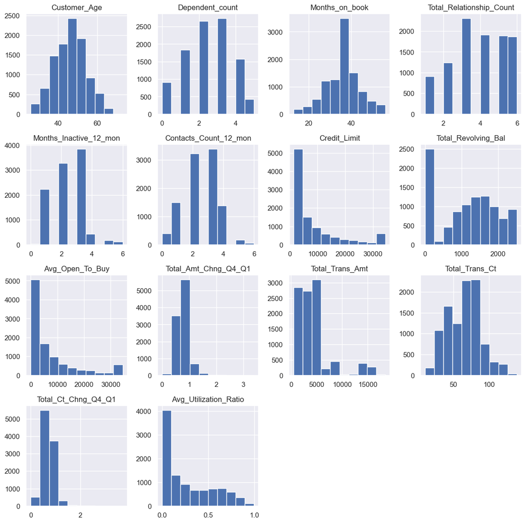

```python
# creating histograms
df[numerical_cols].hist(figsize=(14, 14))
plt.show()
```

## Observations

### Univariate EDA on Categorical variables

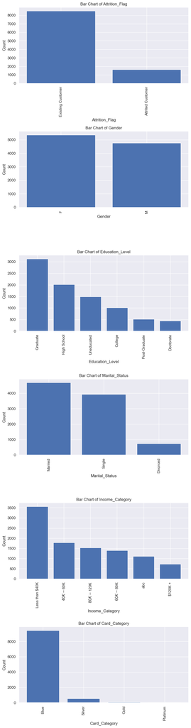

```python
# Create subplots for each categorical column
fig, axes = plt.subplots(len(categorical_cols), 1, figsize=(8, len(categorical_cols)*5))

# Iterate over each categorical column and plot the bar chart
for i, col in enumerate(categorical_cols):
    # Count the occurrences of each category in the column
    value_counts = df[col].value_counts()

    # Plot the bar chart
    axes[i].bar(value_counts.index, value_counts.values)
    axes[i].set_xlabel(col)
    axes[i].set_ylabel('Count')
    axes[i].set_title(f'Bar Chart of {col}')
    axes[i].tick_params(axis='x', rotation=90)

# Adjust the spacing between subplots
plt.tight_layout()

# Display the plots
plt.show()
```

## Observations

### Bivariate EDA

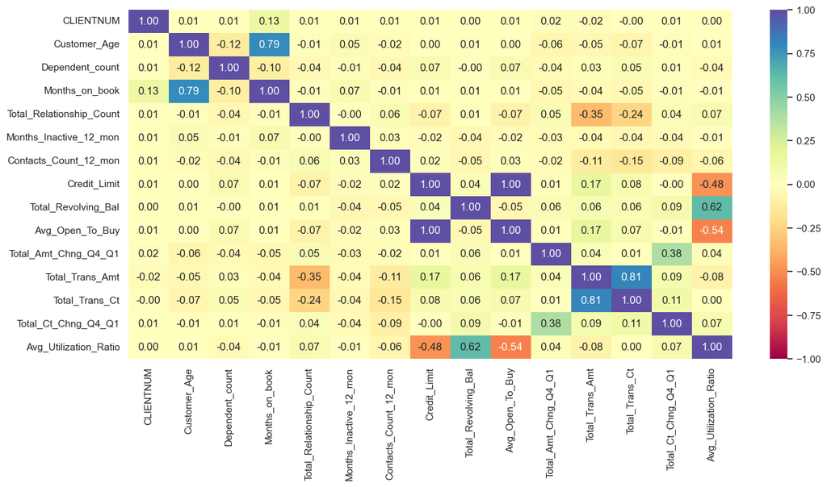

```python
# Let's check how different variables are related to each other.
plt.figure(figsize=(15, 7))
sns.heatmap(data.corr(), annot=True, vmin=-1, vmax=1, fmt=".2f", cmap="Spectral")
plt.show()
```

## Observations

- `Customer_Age` is strongly positively correlated to `Months_on_book`which implies that as customer age increases, they are more likely to stay longer as customers.
- `Credit_Limit` is perfectly positively correlated to `Avg_Open_To_Buy` which implies that customers with higher credit limits are more open to buy credit line.
- `Total_Revolving_Bal` is strongly positively correlated to `Avg_Utilization_Ratio` which implies that customers with higher total revolving balance on the credit card are more likely to use their credit cards more.
- `Total_Amt_Chng_Q4_Q1` is moderately positively correlated to `Total_Ct_Chng_Q4_Q1`which implies that there is tendency for a change in total amount to also result in a change in transaction count.
- `Total_Trans_Amt` is strongly positively correlated to `Total_Trans_Ct`which implies that as total transaction amount increases, total transaction count also increases.
- `Total_Relationship_Count`is moderately negatively correlated to `Total_Trans_Amt` and `Total_Trans_Ct` which implies that as the number of products held by the customers are increasing, there is a chance that the `Total_Trans_Amt` and `Total_Trans_Ct` may decrease.
- `Credit_Limit`is moderately negatively correlated to `Avg_Utilization_Ratio` which implies that credit limit increases, there is a chance that the `Avg_Utilization_Ratio` may decrease.
- `Avg_Open_To_Buy` is moderately negatively correlated to `Avg_Utilization_Ratio` which implies that the more open the customer is to buy credit line there is a chance that the `Avg_Utilization_Ratio` may decrease.

```python
# Mean of numerical variables grouped by attrition
df.groupby(["Attrition_Flag"])[numerical_cols].mean()
```

| Attrition_Flag | Customer_Age | Dependent_count | Months_on_book | Total_Relationship_Count | Months_Inactive_12_mon | Contacts_Count_12_mon | Credit_Limit | Total_Revolving_Bal | Avg_Open_To_Buy | Total_Amt_Chng_Q4_Q1 | Total_Trans_Amt | Total_Trans_Ct | Total_Ct_Chng_Q4_Q1 | Avg_Utilization_Ratio |
| --- | --- | --- | --- | --- | --- | --- | --- | --- | --- | --- | --- | --- | --- | --- |
| Attrited Customer | 46.659 | 2.403 | 36.178 | 3.280 | 2.693 | 2.972 | 8136.039 | 672.823 | 7463.216 | 0.694 | 3095.026 | 44.934 | 0.554 | 0.162 |
| Existing Customer | 46.262 | 2.335 | 35.881 | 3.915 | 2.274 | 2.356 | 8726.878 | 1256.604 | 7470.273 | 0.773 | 4654.656 | 68.673 | 0.742 | 0.296 |

## Observations

- Customers with a higher total Revolving Balance on the Credit Card are more likely to continue to keep their accounts open.
- Customers with a higher `Total_Trans_Amt`, `Total_Trans_Ct`, and `Total_Ct_Chng_Q4_Q1` are more likely to continue to keep their accounts open.

#### `Total_Trans_Amt` vs `Total_Trans_Ct`

[figure not shown]

```python
sns.scatterplot(x='Total_Trans_Amt', y='Total_Trans_Ct', hue='Attrition_Flag', data=df)
plt.show()
```

### Observation

- Above ~ 12500 `Total_Trans_Amt` and ~100 `Total_Trans_Ct` there are no attrited customers shown. This may imply that the customers with higher `Total_Trans_Amt` and `Total_Trans_Ct`are more likely to continue as credit card customers and correlates with what was already shown above.

#### Customer_Age vs Months_on_book

[figure not shown]

```python
sns.scatterplot(x='Customer_Age', y='Months_on_book', hue='Attrition_Flag', data=df)
plt.show()
```

### Observation

- There is no clear `Attrition_Flag` relationship pattern shown.

#### `Credit_Limit`vs `Avg_Open_To_Buy`

[figure not shown]

```python
sns.scatterplot(x='Credit_Limit', y='Avg_Open_To_Buy', hue='Attrition_Flag', data=df)
plt.show()
```

### Observation

- There is no clear `Attrition_Flag` relationship pattern shown.

#### `Total_Revolving_Bal` vs `Avg_Utilization_Ratio`

[figure not shown]

```python
sns.scatterplot(x='Total_Revolving_Bal', y='Avg_Utilization_Ratio', hue='Attrition_Flag', data=df)
plt.show()
```

### Observation

- There is no clear `Attrition_Flag` relationship pattern shown.

#### `Total_Amt_Chng_Q4_Q1`vs `Avg_Utilization_Ratio`

[figure not shown]

```python
sns.scatterplot(x='Total_Amt_Chng_Q4_Q1', y='Avg_Utilization_Ratio', hue='Attrition_Flag', data=df)
plt.show()
```

### Observation

- The majority of customers with more than ~ 1.3 `Total_Amt_Chng_Q4_Q1` are still existing customers.

#### `Total_Relationship_Count`vs `Total_Trans_Amt`

[figure not shown]

```python
sns.scatterplot(x='Total_Relationship_Count', y='Total_Trans_Amt', hue='Attrition_Flag', data=df)
plt.show()
```

### Observation

#### `Avg_Open_To_Buy` vs `Avg_Utilization_Ratio`

[figure not shown]

```python
sns.scatterplot(x='Avg_Open_To_Buy', y='Avg_Utilization_Ratio', hue='Attrition_Flag', data=df)
plt.show()
```

### Observation

- There is no clear `Attrition_Flag` relationship pattern shown.

#### `Attrition_Flag` vs other Categorical variables

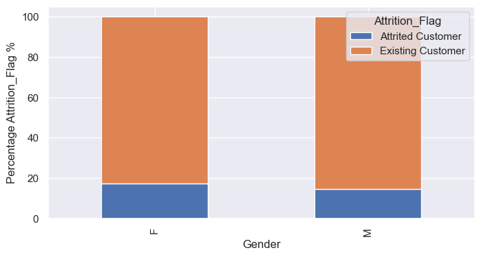

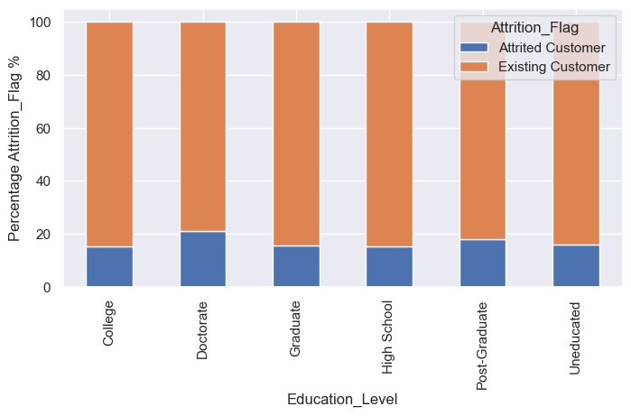

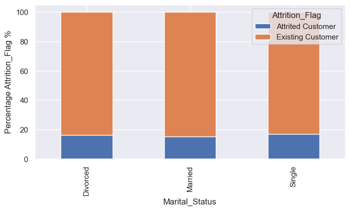

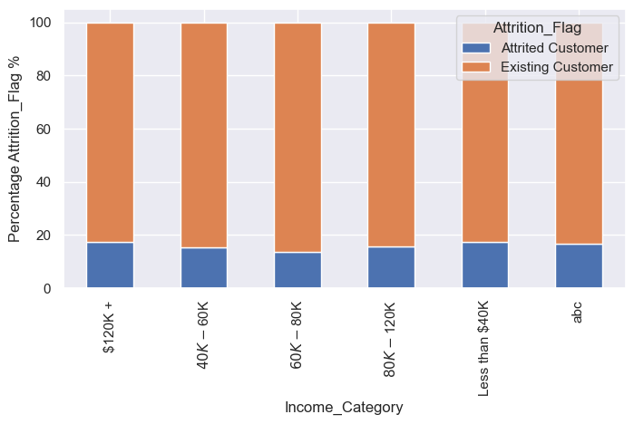

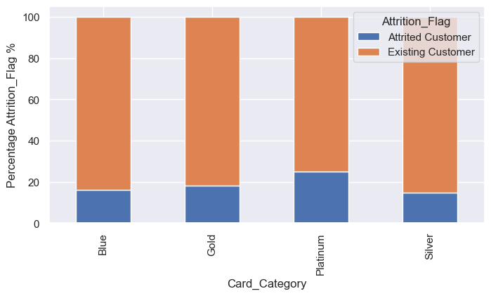

```python
for i in categorical_cols:
    if i != "Attrition_Flag":
        (pd.crosstab(df[i], df["Attrition_Flag"], normalize="index") * 100).plot(
            kind="bar", figsize=(8, 4), stacked=True
        )
        plt.ylabel("Percentage Attrition_Flag %")
```

## Observations

- Males are slighly more likely to to keep their accounts open than females.
- Customers with doctorate have the highest number of attrited customers compared to the other education levels.
- Customers with Platinum credit cards have highest number of attrited customers compared to the other credit card categories.

## Data Pre-processing

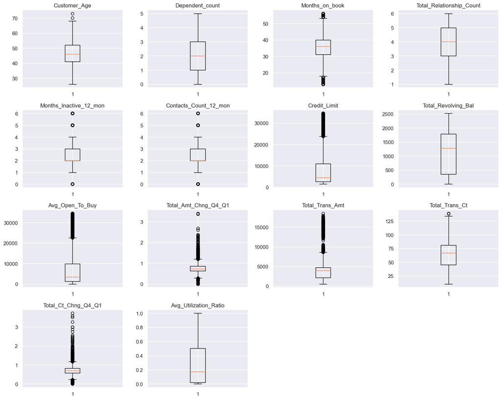

```python
# outlier detection using boxplot

plt.figure(figsize=(15, 12))

for i, variable in enumerate(numerical_cols):
    plt.subplot(4, 4, i + 1)
    plt.boxplot(df[variable], whis=1.5)
    plt.tight_layout()
    plt.title(variable)

plt.show()
```

## Observations

- `Dependent_count`, `Total_Relationship_Count`, `Total_Revolving_Bal` and `Avg_Utilization_Ratio` do not show outliers.
- All other columns show outliers.

```python
# Calculate the interquartile range (IQR)
Q1 = df['Customer_Age'].quantile(0.25)
Q3 = df['Customer_Age'].quantile(0.75)
IQR = Q3 - Q1

# Identify outliers using the IQR method
outliers = df[(df['Customer_Age'] < (Q1 - 1.5 * IQR)) | (df['Customer_Age'] > (Q3 + 1.5 * IQR))]

# Count the number of outliers
num_outliers = len(outliers)

# Print the number of outliers
print("Number of outliers in 'Customer_Age':", num_outliers)
```

```
Number of outliers in 'Customer_Age': 2
```

```python
df['Customer_Age'].max()
```

```
73
```

## Observation

- The maximum age is 73 years old which is reasonable. Therefore, `Customer_Age` outlier will not be treated.

```python
# Calculate the interquartile range (IQR)
Q1 = df['Months_on_book'].quantile(0.25)
Q3 = df['Months_on_book'].quantile(0.75)
IQR = Q3 - Q1

# Identify outliers using the IQR method
outliers = df[(df['Months_on_book'] < (Q1 - 1.5 * IQR)) | (df['Months_on_book'] > (Q3 + 1.5 * IQR))]

# Count the number of outliers
num_outliers = len(outliers)

# Print the number of outliers
print("Number of outliers in 'Months_on_book':", num_outliers)
```

```
Number of outliers in 'Months_on_book': 386
```

```python
df['Months_on_book'].max()
```

```
56
```

## Observation

- The maximum period of relationship with the bank is 56 in months which is reasonable. Therefore, `Months_on_book` outlier will not be treated.

```python
# Calculate the interquartile range (IQR)
Q1 = df['Months_Inactive_12_mon'].quantile(0.25)
Q3 = df['Months_Inactive_12_mon'].quantile(0.75)
IQR = Q3 - Q1

# Identify outliers using the IQR method
outliers = df[(df['Months_Inactive_12_mon'] < (Q1 - 1.5 * IQR)) | (df['Months_Inactive_12_mon'] > (Q3 + 1.5 * IQR))]

# Count the number of outliers
num_outliers = len(outliers)

# Print the number of outliers
print("Number of outliers in 'Months_Inactive_12_mon':", num_outliers)
```

```
Number of outliers in 'Months_Inactive_12_mon': 331
```

```python
df['Months_Inactive_12_mon'].max()
```

```
6
```

## Observation

- The maximum no. of months inactive in the last 12 months is 6 in months which is reasonable. Therefore, `Months_Inactive_12_mon` outlier will not be treated.

```python
# Calculate the interquartile range (IQR)
Q1 = df['Contacts_Count_12_mon'].quantile(0.25)
Q3 = df['Contacts_Count_12_mon'].quantile(0.75)
IQR = Q3 - Q1

# Identify outliers using the IQR method
outliers = df[(df['Contacts_Count_12_mon'] < (Q1 - 1.5 * IQR)) | (df['Contacts_Count_12_mon'] > (Q3 + 1.5 * IQR))]

# Count the number of outliers
num_outliers = len(outliers)

# Print the number of outliers
print("Number of outliers in 'Contacts_Count_12_mon':", num_outliers)
```

```
Number of outliers in 'Contacts_Count_12_mon': 629
```

```python
df['Contacts_Count_12_mon'].max()
```

```
6
```

## Observation

- The maximum no. of Contacts in the last 12 months is 6 which is reasonable. Therefore, `Contacts_Count_12_mon` outlier will not be treated.

```python
# Calculate the interquartile range (IQR)
Q1 = df['Credit_Limit'].quantile(0.25)
Q3 = df['Credit_Limit'].quantile(0.75)
IQR = Q3 - Q1

# Identify outliers using the IQR method
outliers = df[(df['Credit_Limit'] < (Q1 - 1.5 * IQR)) | (df['Credit_Limit'] > (Q3 + 1.5 * IQR))]

# Count the number of outliers
num_outliers = len(outliers)

# Print the number of outliers
print("Number of outliers in 'Credit_Limit':", num_outliers)
```

```
Number of outliers in 'Credit_Limit': 984
```

```python
df['Credit_Limit'].max()
```

```
34516.0
```

## Observation

- The maximum credit limit on the Credit Card is 34516 which is a high but reasonable limit. Therefore, `Credit_Limit` outlier will not be treated.

```python
# Calculate the interquartile range (IQR)
Q1 = df['Avg_Open_To_Buy'].quantile(0.25)
Q3 = df['Avg_Open_To_Buy'].quantile(0.75)
IQR = Q3 - Q1

# Identify outliers using the IQR method
outliers = df[(df['Avg_Open_To_Buy'] < (Q1 - 1.5 * IQR)) | (df['Avg_Open_To_Buy'] > (Q3 + 1.5 * IQR))]

# Count the number of outliers
num_outliers = len(outliers)

# Print the number of outliers
print("Number of outliers in 'Avg_Open_To_Buy':", num_outliers)
```

```
Number of outliers in 'Avg_Open_To_Buy': 963
```

```python
df['Avg_Open_To_Buy'].max()
```

```
34516.0
```

## Observation

- The maximum `Avg_Open_To_Buy` (Average of last 12 months) is 34516 which is reasonable. Therefore, `Avg_Open_To_Buy` outlier will not be treated.

```python
# Calculate the interquartile range (IQR)
Q1 = df['Total_Amt_Chng_Q4_Q1'].quantile(0.25)
Q3 = df['Total_Amt_Chng_Q4_Q1'].quantile(0.75)
IQR = Q3 - Q1

# Identify outliers using the IQR method
outliers = df[(df['Total_Amt_Chng_Q4_Q1'] < (Q1 - 1.5 * IQR)) | (df['Total_Amt_Chng_Q4_Q1'] > (Q3 + 1.5 * IQR))]

# Count the number of outliers
num_outliers = len(outliers)

# Print the number of outliers
print("Number of outliers in 'Total_Amt_Chng_Q4_Q1':", num_outliers)
```

```
Number of outliers in 'Total_Amt_Chng_Q4_Q1': 396
```

```python
df['Total_Amt_Chng_Q4_Q1'].max()
```

```
3.397
```

## Observation

- The maximum `Total_Amt_Chng_Q4_Q1` is ~ 3.4 which is reasonable. Therefore, `Total_Amt_Chng_Q4_Q1` outlier will not be treated.

```python
# Calculate the interquartile range (IQR)
Q1 = df['Total_Trans_Amt'].quantile(0.25)
Q3 = df['Total_Trans_Amt'].quantile(0.75)
IQR = Q3 - Q1

# Identify outliers using the IQR method
outliers = df[(df['Total_Trans_Amt'] < (Q1 - 1.5 * IQR)) | (df['Total_Trans_Amt'] > (Q3 + 1.5 * IQR))]

# Count the number of outliers
num_outliers = len(outliers)

# Print the number of outliers
print("Number of outliers in 'Total_Trans_Amt':", num_outliers)
```

```
Number of outliers in 'Total_Trans_Amt': 896
```

```python
df['Total_Trans_Amt'].max()
```

```
18484
```

## Observation

- The maximum `Total_Trans_Amt` (Last 12 months) is ~ 18400 which is reasonable. Therefore, `Total_Trans_Amt` outlier will not be treated.

```python
# Calculate the interquartile range (IQR)
Q1 = df['Total_Trans_Ct'].quantile(0.25)
Q3 = df['Total_Trans_Ct'].quantile(0.75)
IQR = Q3 - Q1

# Identify outliers using the IQR method
outliers = df[(df['Total_Trans_Ct'] < (Q1 - 1.5 * IQR)) | (df['Total_Trans_Ct'] > (Q3 + 1.5 * IQR))]

# Count the number of outliers
num_outliers = len(outliers)

# Print the number of outliers
print("Number of outliers in 'Total_Trans_Ct':", num_outliers)
```

```
Number of outliers in 'Total_Trans_Ct': 2
```

```python
df['Total_Trans_Ct'].max()
```

```
139
```

## Observation

- The maximum `Total_Trans_Ct` is 139 which is reasonable. Therefore, `Total_Trans_Ct` outlier will not be treated.

```python
# Calculate the interquartile range (IQR)
Q1 = df['Total_Ct_Chng_Q4_Q1'].quantile(0.25)
Q3 = df['Total_Ct_Chng_Q4_Q1'].quantile(0.75)
IQR = Q3 - Q1

# Identify outliers using the IQR method
outliers = df[(df['Total_Ct_Chng_Q4_Q1'] < (Q1 - 1.5 * IQR)) | (df['Total_Ct_Chng_Q4_Q1'] > (Q3 + 1.5 * IQR))]

# Count the number of outliers
num_outliers = len(outliers)

# Print the number of outliers
print("Number of outliers in 'Total_Ct_Chng_Q4_Q1':", num_outliers)
```

```
Number of outliers in 'Total_Ct_Chng_Q4_Q1': 394
```

```python
df['Total_Ct_Chng_Q4_Q1'].max()
```

```
3.714
```

## Observation

- The maximum `Total_Ct_Chng_Q4_Q1` is ~ 3.7 which is reasonable. Therefore, `Total_Ct_Chng_Q4_Q1` outlier will not be treated.

```python
print(df.Attrition_Flag.value_counts())
print(df.Customer_Age.value_counts())
print(df.Gender.value_counts())
print(df.Dependent_count.value_counts())
print(df.Education_Level.value_counts())
print(df.Marital_Status.value_counts())
print(df.Income_Category.value_counts())
print(df.Card_Category.value_counts())
print(df.Months_on_book.value_counts())
print(df.Total_Relationship_Count.value_counts())
print(df.Months_Inactive_12_mon.value_counts())
print(df.Contacts_Count_12_mon.value_counts())
print(df.Credit_Limit.value_counts())
print(df.Total_Revolving_Bal.value_counts())
print(df.Avg_Open_To_Buy.value_counts())
print(df.Total_Amt_Chng_Q4_Q1.value_counts())
print(df.Total_Trans_Amt.value_counts())
print(df.Total_Trans_Ct.value_counts())
print(df.Total_Ct_Chng_Q4_Q1.value_counts())
print(df.Avg_Utilization_Ratio.value_counts())
```

[output not shown]

[output cut: 191 more lines]

```
0.125      1
0.359      1
Name: Total_Ct_Chng_Q4_Q1, Length: 830, dtype: int64
0.000    2470
0.073      44
0.057      33
0.048      32
0.060      30
         ...
0.927       1
0.935       1
0.954       1
0.385       1
0.009       1
Name: Avg_Utilization_Ratio, Length: 964, dtype: int64
```

```python
df['Attrition_Flag'].value_counts()
```

```
Existing Customer    8500
Attrited Customer    1627
Name: Attrition_Flag, dtype: int64
```

```python
df.head()
```

[output not shown]

```python
df["Attrition_Flag"].replace({"Existing Customer": 1, "Attrited Customer": 0}, inplace=True)
```

```python
# Let's separate target variable and other variables
X = df.drop(columns="Attrition_Flag")

Y = df["Attrition_Flag"]
```

```python
df.head()
```

|  | Attrition_Flag | Customer_Age | Gender | Dependent_count | Education_Level | Marital_Status | Income_Category | Card_Category | Months_on_book | Total_Relationship_Count | Months_Inactive_12_mon | Contacts_Count_12_mon | Credit_Limit | Total_Revolving_Bal | Avg_Open_To_Buy | Total_Amt_Chng_Q4_Q1 | Total_Trans_Amt | Total_Trans_Ct | Total_Ct_Chng_Q4_Q1 | Avg_Utilization_Ratio |
| --- | --- | --- | --- | --- | --- | --- | --- | --- | --- | --- | --- | --- | --- | --- | --- | --- | --- | --- | --- | --- |
| 0 | 1 | 45 | M | 3 | High School | Married | $60K - $80K | Blue | 39 | 5 | 1 | 3 | 12691.000 | 777 | 11914.000 | 1.335 | 1144 | 42 | 1.625 | 0.061 |
| 1 | 1 | 49 | F | 5 | Graduate | Single | Less than $40K | Blue | 44 | 6 | 1 | 2 | 8256.000 | 864 | 7392.000 | 1.541 | 1291 | 33 | 3.714 | 0.105 |
| 2 | 1 | 51 | M | 3 | Graduate | Married | $80K - $120K | Blue | 36 | 4 | 1 | 0 | 3418.000 | 0 | 3418.000 | 2.594 | 1887 | 20 | 2.333 | 0.000 |
| 3 | 1 | 40 | F | 4 | High School | NaN | Less than $40K | Blue | 34 | 3 | 4 | 1 | 3313.000 | 2517 | 796.000 | 1.405 | 1171 | 20 | 2.333 | 0.760 |
| 4 | 1 | 40 | M | 3 | Uneducated | Married | $60K - $80K | Blue | 21 | 5 | 1 | 0 | 4716.000 | 0 | 4716.000 | 2.175 | 816 | 28 | 2.500 | 0.000 |

```python
# Splitting data into training, validation and test set:
# first we split data into 2 parts, say temporary and test

X_temp, X_test, Y_temp, Y_test = train_test_split(
    X, Y, test_size=0.2, random_state=1, stratify=Y)

# then we split the temporary set into train and validation

X_train, X_val, Y_train, Y_val = train_test_split(
    X_temp, Y_temp, test_size=0.25, random_state=1, stratify=Y_temp
)
print(X_train.shape, X_val.shape, X_test.shape)
```

```
(6075, 19) (2026, 19) (2026, 19)
```